# Assignment 3: Image Colourization [50 Pt]

## Part 3 Skip Connections [5 pt]

A skip connection in a neural network is a connection which skips one or more layer and connects to a later layer. In this section we will be incorporating skip connections to improve on our model architecture.

### Part (i) [2pt MODEL]

In this task, modify the original RegressionCNN class to implement a U-Net architecture by adding skip connections between the corresponding layers in the encoder and decoder (i.e., Add a skip connection from the first layer to the last, second layer to the second last, etc.). Specifically, the output of each downsampling block should be concatenated with the output of the corresponding upsampling block. For example, the input to upconv1 should be the concatenation of the output of rfconv and the output of downconv2. You will need to use torch.cat() to concatenate the feature maps along the channel dimension. Ensure the channel dimensions match after concatenation, possibly by adjusting the number of filters where necessary. The final convolution should have both the output of the previous layer and the initial greyscale input as input. Please complete the **init** and forward methods of the UNet class below. Hint: You will not need to update the downsampling part but you would need to update upsampling part and the final layer.

```python
#complete the code

class UNet(nn.Module):
    def __init__(self, kernel, num_filters, num_colours=3, num_in_channels=1):
        super().__init__()

        # Useful parameters
        stride = 2
        padding = kernel // 2
        output_padding = 1

        ############### YOUR CODE GOES HERE ###############
        ###################################################

        # --------- Encoder (No Chnage) ---------
        self.downconv1 = nn.Sequential(
            nn.Conv2d(num_in_channels, num_filters, kernel_size=kernel, padding=padding),                 # d1_in -> [B, 1, 32, 32]
            nn.BatchNorm2d(num_filters),
            nn.ReLU(),
            nn.MaxPool2d(2),)                                                               # d1_out -> [B, F, 16, 16]
        self.downconv2 = nn.Sequential(
            nn.Conv2d(num_filters, num_filters*2, kernel_size=kernel, padding=padding),     # d2_in -> [B, 2F, 16, 16]
            nn.BatchNorm2d(num_filters*2),
            nn.ReLU(),
            nn.MaxPool2d(2),)                                                               # d2_out -> [B, 2F, 8, 8]

        # --------- Bottleneck ---------
        self.rfconv = nn.Sequential(
            nn.Conv2d(num_filters*2, num_filters*2, kernel_size=kernel, padding=padding),   # f -> [B, 2F, 8, 8]
            nn.BatchNorm2d(num_filters*2),
            nn.ReLU())

        # --------- Decoder ---------
        self.upconv1 = nn.Sequential(
            nn.Conv2d(num_filters*4, num_filters, kernel_size=kernel, padding=padding),     # u1_in -> concat(d2_out, rf) -> [B, 2F+2F, 8, 8]
            nn.BatchNorm2d(num_filters),
            nn.ReLU(),
            nn.Upsample(scale_factor=2),)                                                   # u1_out -> [B, F, 16, 16]
        self.upconv2 = nn.Sequential(
            nn.Conv2d(num_filters*2, num_colours, kernel_size=kernel, padding=padding),     # u2_in -> concat(d1_out, u1_out) -> [B, F+F, 16, 16]
            nn.BatchNorm2d(3),
            nn.ReLU(),
            nn.Upsample(scale_factor=2),)                                                   # u2_out -> [B, 3, 32, 32]
        self.finalconv = nn.Conv2d(num_in_channels+num_colours, num_colours, kernel_size=kernel, padding=padding)
                                                                                            # final_in -> concat(x, u2_out) -> [B, 1+3, 32, 32]
                                                                                            # final_out -> [B, 3, 32, 32]



    def forward(self, x):
        ############### YOUR CODE GOES HERE ###############
        ###################################################
        d1 = self.downconv1(x)
        d2 = self.downconv2(d1)
        rf = self.rfconv(d2)
        u1_in = torch.cat([d2, rf], dim=1)
        u1 = self.upconv1(u1_in)
        u2_in = torch.cat([d1, u1], dim=1)
        u2 = self.upconv2(u2_in)
        final_in = torch.cat([u2, x], dim=1)
        out = self.finalconv(final_in)

        return out
```

### Part (ii) [2pt RESULTS]

Train the "UNet" model for the same amount of epochs as the previous CNN and plot the training curve using a batch size of 100. You might want to update the train function to plot the training curve.

```
Loading data...
File path: data/cifar-10-batches-py.tar.gz
Transforming data...
Beginning training ...
[epoch 000] train_loss=0.086549 (logged)
[epoch 005] train_loss=0.010548 (logged)
[epoch 010] train_loss=0.007449 (logged)
[epoch 015] train_loss=0.006253 (logged)
[epoch 020] train_loss=0.005443 (logged)
[epoch 025] train_loss=0.004896 (logged)
[epoch 030] train_loss=0.004498 (logged)
[epoch 035] train_loss=0.004200 (logged)
[epoch 040] train_loss=0.003952 (logged)
[epoch 045] train_loss=0.003745 (logged)
[epoch 050] train_loss=0.003556 (logged)
```

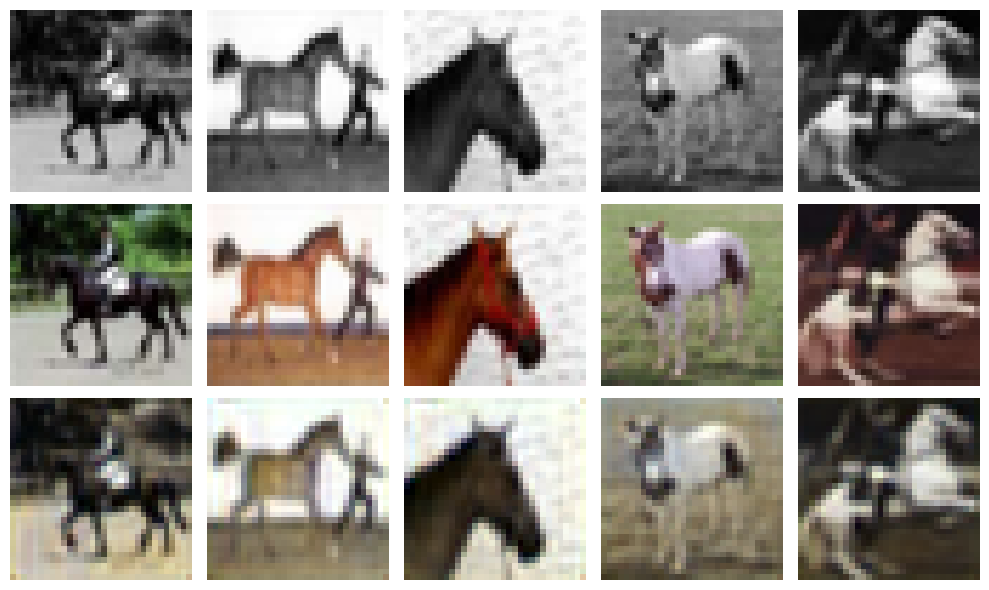

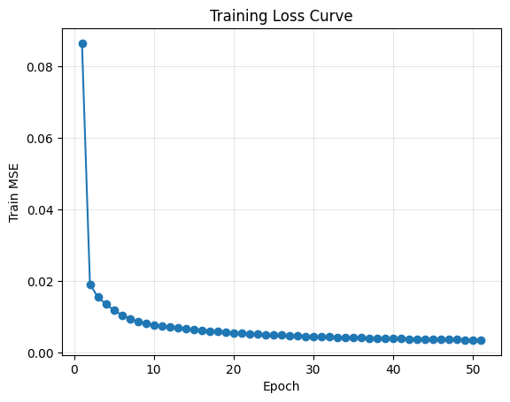

```
Training done. CSV logged. Loss curve displayed (not saved).
```

```python
# Main training loop for UNet
args = AttrDict()
args_dict = {
    "gpu": True,
    "valid": False,
    "checkpoint": "",
    "colours": "./data/colours/colour_kmeans24_cat7.npy",
    "model": "UNet",
    "kernel": 3,
    "num_filters": 32,
    'learn_rate':0.001,
    "batch_size": 100,
    "epochs": 51,
    "seed": 0,
    "plot": True,
    "experiment_name": "colourization_cnn",
    "visualize": False,
    "downsize_input": False,
}
args.update(args_dict)
cnn = train(args)
```

How does the result compare to the previous model? Did skip connections improve the loss? Did the skip connections improve the output qualitatively? How? Give at least two reasons why skip connections might improve the performance of our CNN models.

```python
'''
PROVIDE YOUR ANSWER BELOW

Compared with my earlier AE , the U-Net consistently converged faster and to a lower (or at least more stable) MSE,
and produced visibly sharper results: object boundaries (mane/legs, horizon) are crisper and color bleed is reduced, with more coherent sky/grass hues.

Yes—skip connections improved the loss and the qualitative output.

Why skips help:

1. They enhance gradient flow (identity shortcuts), mitigating vanishing gradients and easing optimization.
2. They pass high-frequency encoder features (edges/textures) directly to the decoder, reducing blur.
3. Multi-scale fusion (shallow + deep features) improves localization while preserving semantics.




'''
```

### Part (iii) [1pt RESULTS]

Re-train a few more "UNet" models using different mini batch sizes with a fixed number of epochs.

```
Loading data...
File path: data/cifar-10-batches-py.tar.gz
Transforming data...
Beginning training ...
[epoch 000] train_loss=0.040178 (logged)
[epoch 005] train_loss=0.007138 (logged)
[epoch 010] train_loss=0.005612 (logged)
[epoch 015] train_loss=0.004849 (logged)
[epoch 020] train_loss=0.004382 (logged)
[epoch 025] train_loss=0.004047 (logged)
[epoch 030] train_loss=0.003778 (logged)
[epoch 035] train_loss=0.003529 (logged)
[epoch 040] train_loss=0.003312 (logged)
[epoch 045] train_loss=0.003091 (logged)
[epoch 050] train_loss=0.002873 (logged)
[epoch 055] train_loss=0.002690 (logged)
[epoch 060] train_loss=0.002682 (logged)
[epoch 065] train_loss=0.002455 (logged)
[epoch 070] train_loss=0.002328 (logged)
[epoch 075] train_loss=0.002262 (logged)
```

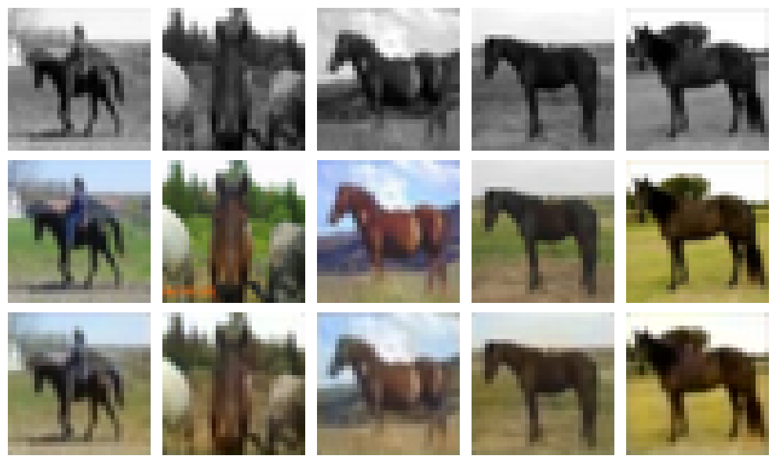

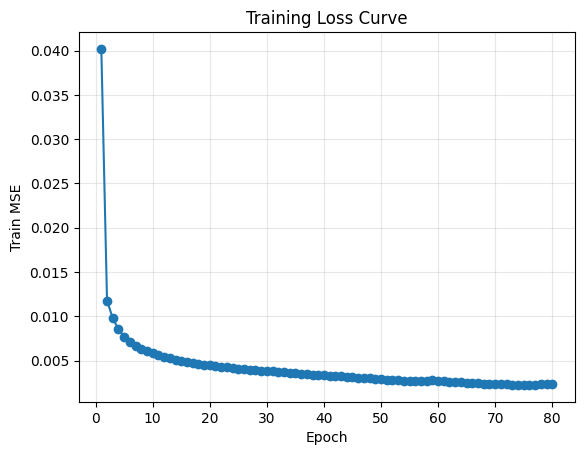

```
Training done. CSV logged. Loss curve displayed (not saved).
```

```python
# Model 1 - batch size 64 & epoch 80
args = AttrDict()
args_dict = {
    "gpu": True,
    "valid": False,
    "checkpoint": "",
    "colours": "./data/colours/colour_kmeans24_cat7.npy",
    "model": "UNet",
    "kernel": 3,
    "num_filters": 32,
    'learn_rate':0.001,
    "batch_size": 64,
    "epochs": 80,
    "seed": 0,
    "plot": True,
    "experiment_name": "colourization_cnn",
    "visualize": False,
    "downsize_input": False,
}
args.update(args_dict)
cnn = train(args)
```

```
Loading data...
File path: data/cifar-10-batches-py.tar.gz
Transforming data...
Beginning training ...
[epoch 000] train_loss=0.036500 (logged)
[epoch 005] train_loss=0.005794 (logged)
[epoch 010] train_loss=0.004450 (logged)
[epoch 015] train_loss=0.003870 (logged)
[epoch 020] train_loss=0.003532 (logged)
[epoch 025] train_loss=0.003289 (logged)
[epoch 030] train_loss=0.003085 (logged)
[epoch 035] train_loss=0.002880 (logged)
[epoch 040] train_loss=0.002706 (logged)
[epoch 045] train_loss=0.002544 (logged)
[epoch 050] train_loss=0.002407 (logged)
[epoch 055] train_loss=0.002335 (logged)
[epoch 060] train_loss=0.002231 (logged)
[epoch 065] train_loss=0.002169 (logged)
[epoch 070] train_loss=0.002072 (logged)
[epoch 075] train_loss=0.001971 (logged)
```

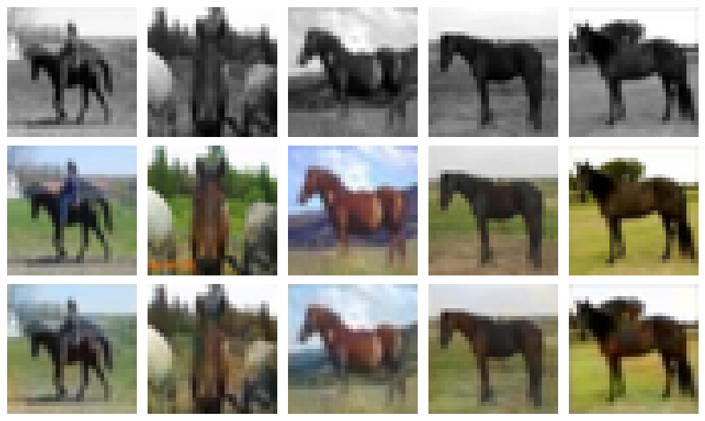

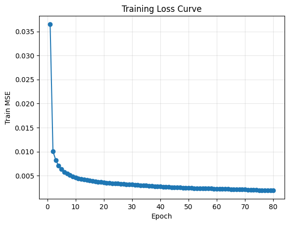

```
Training done. CSV logged. Loss curve displayed (not saved).
```

```python
# Model 2 - batch size 32 & epoch 80
args = AttrDict()
args_dict = {
    "gpu": True,
    "valid": False,
    "checkpoint": "",
    "colours": "./data/colours/colour_kmeans24_cat7.npy",
    "model": "UNet",
    "kernel": 3,
    "num_filters": 32,
    'learn_rate':0.001,
    "batch_size": 32,
    "epochs": 80,
    "seed": 0,
    "plot": True,
    "experiment_name": "colourization_cnn",
    "visualize": False,
    "downsize_input": False,
}
args.update(args_dict)
cnn = train(args)
```

```
Loading data...
File path: data/cifar-10-batches-py.tar.gz
Transforming data...
Beginning training ...
[epoch 000] train_loss=0.015151 (logged)
[epoch 005] train_loss=0.004238 (logged)
[epoch 010] train_loss=0.003517 (logged)
[epoch 015] train_loss=0.003190 (logged)
[epoch 020] train_loss=0.002914 (logged)
[epoch 025] train_loss=0.002660 (logged)
[epoch 030] train_loss=0.002443 (logged)
[epoch 035] train_loss=0.002269 (logged)
[epoch 040] train_loss=0.002149 (logged)
[epoch 045] train_loss=0.002054 (logged)
[epoch 050] train_loss=0.001991 (logged)
[epoch 055] train_loss=0.001942 (logged)
[epoch 060] train_loss=0.001897 (logged)
[epoch 065] train_loss=0.001893 (logged)
[epoch 070] train_loss=0.001866 (logged)
[epoch 075] train_loss=0.001812 (logged)
```

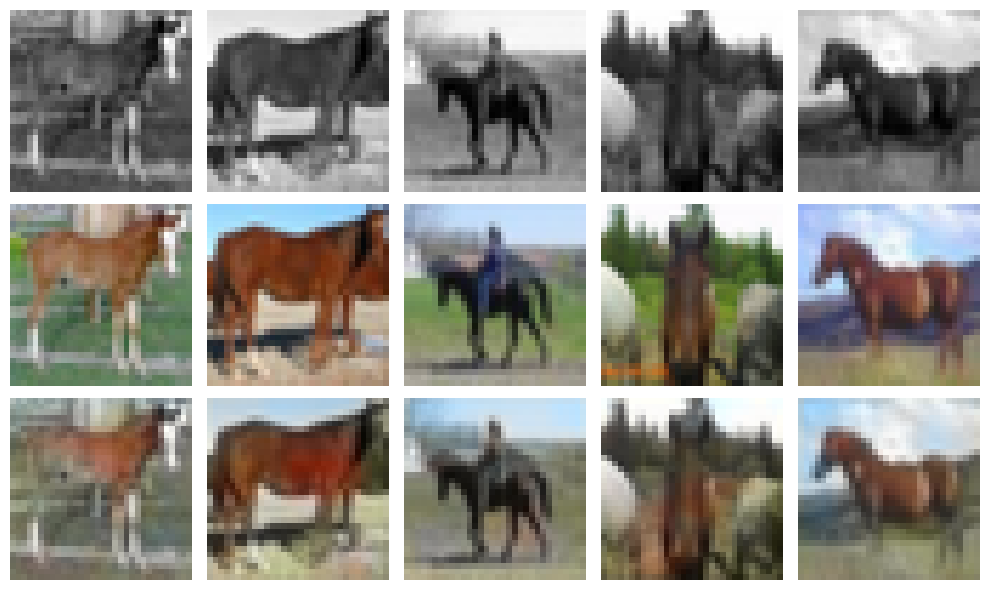

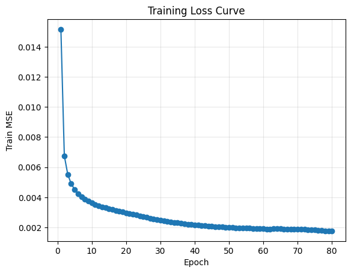

```
Training done. CSV logged. Loss curve displayed (not saved).
```

```python
# Model 1 - batch size 10 & epoch 80
args = AttrDict()
args_dict = {
    "gpu": True,
    "valid": False,
    "checkpoint": "",
    "colours": "./data/colours/colour_kmeans24_cat7.npy",
    "model": "UNet",
    "kernel": 3,
    "num_filters": 32,
    'learn_rate':0.001,
    "batch_size": 10,
    "epochs": 80,
    "seed": 0,
    "plot": True,
    "experiment_name": "colourization_cnn",
    "visualize": False,
    "downsize_input": False,
}
args.update(args_dict)
cnn = train(args)
```

Describe the effect of batch sizes on the loss and the final image output.

```python
'''
PROVIDE YOUR ANSWER BELOW

Loss:
Larger batches (64) give smoother, lower-variance loss curves but can settle in “flat, average” minima; small batches (10) has loss jiggled more, which is shown by inconsistant loss drop for every 5 epoch,
and may need LR tuning.


Images:
B64 looks more uniform yet softer/desaturated (blurry grass/coat); B32 is a decent trade-off—reasonable sharpness and stable colors; B10 tends to be more saturated with occasional inconsistency across samples.

To sum up, for this UNet+MSE setup, a moderate batch (≈32) balances stability and detail




'''
```

# PART B - Conditional GAN

In this second half of the assignment we will construct a conditional generative adversarial network for our image colourization task. This second half of the assignment should be started after the lecture on generative adversarial networks (GANs).

## Part 1 Conditional GAN [10 Pt]

To start we will be modifying the previous sample code to construct and train a conditional GAN. Later you will have the opportunity to explore other modifications that can be made to our architecture to achieve the best results on image colourization model.

### Part (i) [2pt MODEL]

Modify the below code to implement a generator. Then test to verify it works on the desired input (e.g., you could pass few inputs to your generator to verify it works with no errors). You should reuse one of your earlier autoencoder models from Part A here to act as a generator, when you do so, the architecture will be more like the pix2pix architecture (see https://phillipi.github.io/pix2pix/ for more details).

```python
class Generator(nn.Module):
    def __init__(self, kernel, num_filters, num_colours=3, num_in_channels=1):
        super().__init__()

        # Useful parameters
        stride = 2
        padding = kernel // 2
        output_padding = 1

        ############### YOUR CODE GOES HERE ###############
        ###################################################

        # --------- Encoder (No Chnage) ---------
        self.downconv1 = nn.Sequential(
            nn.Conv2d(num_in_channels, num_filters, kernel_size=kernel, padding=padding),                 # d1_in -> [B, 1, 32, 32]
            nn.BatchNorm2d(num_filters),
            nn.ReLU(),
            nn.MaxPool2d(2),)                                                               # d1_out -> [B, F, 16, 16]
        self.downconv2 = nn.Sequential(
            nn.Conv2d(num_filters, num_filters*2, kernel_size=kernel, padding=padding),     # d2_in -> [B, 2F, 16, 16]
            nn.BatchNorm2d(num_filters*2),
            nn.ReLU(),
            nn.MaxPool2d(2),)                                                               # d2_out -> [B, 2F, 8, 8]

        # --------- Bottleneck ---------
        self.rfconv = nn.Sequential(
            nn.Conv2d(num_filters*2, num_filters*2, kernel_size=kernel, padding=padding),   # f -> [B, 2F, 8, 8]
            nn.BatchNorm2d(num_filters*2),
            nn.ReLU())

        # --------- Decoder ---------
        self.upconv1 = nn.Sequential(
            nn.Conv2d(num_filters*4, num_filters, kernel_size=kernel, padding=padding),     # u1_in -> concat(d2_out, rf) -> [B, 2F+2F, 8, 8]
            nn.BatchNorm2d(num_filters),
            nn.ReLU(),
            nn.Upsample(scale_factor=2),)                                                   # u1_out -> [B, F, 16, 16]
        self.upconv2 = nn.Sequential(
            nn.Conv2d(num_filters*2, num_colours, kernel_size=kernel, padding=padding),     # u2_in -> concat(d1_out, u1_out) -> [B, F+F, 16, 16]
            nn.BatchNorm2d(num_colours),
            nn.ReLU(),
            nn.Upsample(scale_factor=2),)                                                   # u2_out -> [B, 3, 32, 32]
        self.finalconv = nn.Conv2d(num_in_channels+num_colours, num_colours, kernel_size=kernel, padding=padding)
                                                                                            # final_in -> concat(x, u2_out) -> [B, 1+3, 32, 32]
                                                                                            # final_out -> [B, 3, 32, 32]
        self.out_act = nn.Sigmoid()



    def forward(self, x):
        ############### YOUR CODE GOES HERE ###############
        ###################################################
        d1 = self.downconv1(x)
        d2 = self.downconv2(d1)
        rf = self.rfconv(d2)
        u1_in = torch.cat([d2, rf], dim=1)
        u1 = self.upconv1(u1_in)
        u2_in = torch.cat([d1, u1], dim=1)
        u2 = self.upconv2(u2_in)
        final_in = torch.cat([u2, x], dim=1)
        out = self.finalconv(final_in)

        return self.out_act(out)
```

Write code to test that the generator works as intended. No training is needed—simply pass random inputs to the generator to ensure it functions correctly and that the output shapes match your expectations.

```python
# TO BE COMPLETED

B, H, W = 4, 32, 32
net = Generator(kernel=3, num_filters=32, num_colours=3, num_in_channels=1)
x = torch.randn(B, 1, H, W)
y = net(x)
assert y.shape == (B, 3, H, W)
print("OK:", y.shape)
```

```
OK: torch.Size([4, 3, 32, 32])
```

### Part (ii) [2pt MODEL]

Modify the below code to implement a discriminator. You will build a CNN-based discriminator that takes a color image and its corresponding grayscale image as inputs and outputs a single probability (real or fake).

Your discriminator should contain two convolutional layers that progressively increase the number of feature maps (num_filters → num_filters * 2), followed by a fully connected network for classification. You should also use LeakyReLU activations and dropout after each convolutional layer to improve stability.

```python
# discriminator code

class Discriminator(nn.Module):
    def __init__(self, kernel, num_filters, num_colours=3, num_in_channels=1):
        super().__init__()

        # Useful parameters
        stride = 2
        padding = kernel // 2
        output_padding = 1

        ############### YOUR CODE GOES HERE ###############
        ###################################################

        in_c = num_colours + num_in_channels  # 3 + 1 = 4
        nf   = num_filters

        # 2 x Conv blocks: nf -> 2*nf
        self.conv1 = nn.Sequential(
            nn.Conv2d(in_c, nf, kernel_size=kernel, stride=stride, padding=padding, bias=False),
            nn.LeakyReLU(0.2, inplace=True),
            nn.Dropout2d(0.25),
        )
        self.conv2 = nn.Sequential(
            nn.Conv2d(nf, 2*nf, kernel_size=kernel, stride=stride, padding=padding, bias=False),
            nn.LeakyReLU(0.2, inplace=True),
            nn.Dropout2d(0.25),
        )

        # GAP -> FC (small MLP) -> prob
        self.gap = nn.AdaptiveAvgPool2d(1)
        self.fc  = nn.Sequential(
            nn.Flatten(),                      # [B, 2*nf, 1, 1] -> [B, 2*nf]
            nn.Linear(2*nf, 2*nf),
            nn.LeakyReLU(0.2, inplace=True),
            nn.Dropout(0.5),
            nn.Linear(2*nf, 1),
            nn.Sigmoid(),
        )



    def forward(self, x, img_greyscale):

        ############### YOUR CODE GOES HERE ###############
        ###################################################
        inp = torch.cat([x, img_greyscale], dim=1)  # [B, 3+1, H, W]
        h = self.conv1(inp)
        h = self.conv2(h)
        h = self.gap(h)
        out = self.fc(h)                            # [B, 1]
        return out


        return out
```

Write code to test that the discriminator is working as intended. No training is needed—simply pass random inputs to the discriminator to ensure it functions correctly and that the output shapes match your expectations.

```python
# TO BE COMPLETED
# Minimal smoke test for your Discriminator (no training)

import torch

B, H, W = 4, 64, 64
net = Discriminator(kernel=3, num_filters=32, num_colours=3, num_in_channels=1)

x_rgb = torch.randn(B, 3, H, W)   # random color images
x_g   = torch.randn(B, 1, H, W)   # random grayscale images

p = net(x_rgb, x_g)               # forward only
assert p.shape == (B, 1), f"Got {p.shape}, expected {(B,1)}"
print("OK:", p.shape)
```

```
OK: torch.Size([4, 1])
```

### Part (iii) [2pt MODEL]

Modify the provided training code to implement the training needed for a conditional GAN.

Your function should also plot the generator and discriminator losses over the training epochs on the same graph to visualize adversarial training dynamics.

```python
class AttrDict(dict):
    def __init__(self, *args, **kwargs):
        super(AttrDict, self).__init__(*args, **kwargs)
        self.__dict__ = self


def train(args, cnn=None):
    # Limit CPU threads to avoid oversubscription on shared machines
    torch.set_num_threads(5)

    # Reproducibility
    npr.seed(args.seed)

    # Output folder (not used for saving plots in this version)
    save_dir = "outputs/" + args.experiment_name
    if not os.path.exists(save_dir):
        os.makedirs(save_dir)

    # INPUT CHANNEL: grayscale unless downsized to RGB by your preprocessing
    num_in_channels = 1 if not args.downsize_input else 3

    # Load generator (your UNet/Generator)
    if cnn is None:
        Net = globals()[args.model]
        cnn = Net(args.kernel, args.num_filters, num_colours=3, num_in_channels=num_in_channels)

    # TODO: initialize the discriminator model (similar to how cnn is initialized)
    DiscNet = globals().get("Discriminator")
    assert DiscNet is not None, "Discriminator class must exist in globals()."
    discriminator = DiscNet(args.kernel, args.num_filters, num_colours=3, num_in_channels=num_in_channels)

    # LOSS FUNCTION
    # TODO: Use Binary Cross-Entropy loss
    # Note: this assumes your Discriminator ends with Sigmoid. If you switch to logits, use BCEWithLogitsLoss.
    criterion = nn.BCELoss()

    # TODO: Define separate optimizers for generator and discriminator
    lr = getattr(args, "lr", getattr(args, "learning_rate", 2e-4))
    betas = (0.5, 0.999)
    g_optimizer = torch.optim.Adam(cnn.parameters(), lr=lr, betas=betas)
    d_optimizer = torch.optim.Adam(discriminator.parameters(), lr=lr, betas=betas)

    # DATA
    print("Loading data...")
    (x_train, y_train), (x_test, y_test) = load_cifar10()

    print("Transforming data...")
    train_rgb, train_grey = process(x_train, y_train, downsize_input=args.downsize_input)
    test_rgb,  test_grey  = process(x_test,  y_test,  downsize_input=args.downsize_input)

    print("Beginning training ...")
    if args.gpu:
        cnn.cuda()
        discriminator.cuda()

    # Track epoch-averaged losses for both networks
    G_losses, D_losses = [], []
    last_batch_cache = None  # will store (img_grey, img_real, img_fake) from the last iteration

    for epoch in range(args.epochs):
        cnn.train()
        discriminator.train()

        epoch_g, epoch_d, nbatches = 0.0, 0.0, 0

        for xs, ys in get_batch(train_grey, train_rgb, args.batch_size):
            nbatches += 1

            # Get tensors: img_grey -> condition, img_real -> ground-truth RGB
            images, labels = get_torch_vars(xs, ys, args.gpu)   # images: [B,1,H,W], labels: [B,3,H,W]
            img_grey = images
            img_real = labels
            device = images.device

            # --------------------- Train Discriminator ---------------------
            d_optimizer.zero_grad()

            # TODO: Compute loss on real images
            D_real = discriminator(img_real, img_grey)
            real_labels = torch.ones_like(D_real, device=device)
            d_real_loss = criterion(D_real, real_labels)

            # TODO: Compute loss on fake images
            with torch.no_grad():
                img_fake_detached = cnn(img_grey)
            D_fake = discriminator(img_fake_detached, img_grey)
            fake_labels = torch.zeros_like(D_fake, device=device)
            d_fake_loss = criterion(D_fake, fake_labels)

            # TODO: Combine losses and update D
            d_loss = d_real_loss + d_fake_loss
            d_loss.backward()
            d_optimizer.step()

            # --------------------- Train Generator ------------------------
            g_optimizer.zero_grad()
            img_fake = cnn(img_grey)
            D_fake_for_g = discriminator(img_fake, img_grey)

            # TODO: Compute g_loss (generator tries to fool D → target ones)
            g_loss = criterion(D_fake_for_g, torch.ones_like(D_fake_for_g, device=device))
            g_loss.backward()
            g_optimizer.step()

            epoch_g += g_loss.item()
            epoch_d += d_loss.item()

            # cache last mini-batch for visualization after training
            last_batch_cache = (img_grey, img_real, img_fake)

        # Average losses over the epoch
        avg_g = epoch_g / max(1, nbatches)
        avg_d = epoch_d / max(1, nbatches)
        G_losses.append(avg_g)
        D_losses.append(avg_d)

        # >>> print every 5 epochs <<<
        if epoch % 5 == 0:
            print(f"[epoch {epoch:03d}] G_loss={avg_g:.6f}  D_loss={avg_d:.6f} (logged)")

    # Show loss curves (on the same figure, no saving)
    import matplotlib.pyplot as plt
    plt.figure(figsize=(6,4))
    xs = list(range(len(G_losses)))
    plt.plot(xs, G_losses, label="Generator loss")
    plt.plot(xs, D_losses, label="Discriminator loss")
    plt.xlabel("Epoch")
    plt.ylabel("Loss")
    plt.title("cGAN Training Losses")
    plt.legend()
    plt.tight_layout()
    plt.show()

    # Visualize several samples from the last batch using your provided visual()
    if last_batch_cache is not None:
        img_grey, img_real, img_fake = last_batch_cache
        visual(img_grey, img_real, img_fake, gpu=args.gpu, flag_torch=0, losses=None)

    return cnn
```

### Part (iv) [1pt RESULTS]

Train a conditional GAN for image colourization, include your interpretation of the training graphs, and comment on how the results compare to the autoencoder architectures from part A.

```
Loading data...
File path: data/cifar-10-batches-py.tar.gz
Transforming data...
Beginning training ...
[epoch 000] G_loss=0.704075  D_loss=1.385661 (logged)
[epoch 005] G_loss=0.705181  D_loss=1.363430 (logged)
[epoch 010] G_loss=0.845817  D_loss=1.215133 (logged)
[epoch 015] G_loss=1.249028  D_loss=0.962995 (logged)
[epoch 020] G_loss=1.808923  D_loss=0.766564 (logged)
[epoch 025] G_loss=2.428006  D_loss=0.610399 (logged)
[epoch 030] G_loss=3.014707  D_loss=0.511088 (logged)
[epoch 035] G_loss=3.486336  D_loss=0.453019 (logged)
[epoch 040] G_loss=3.843670  D_loss=0.455357 (logged)
[epoch 045] G_loss=4.329464  D_loss=0.423312 (logged)
[epoch 050] G_loss=4.900651  D_loss=0.373650 (logged)
[epoch 055] G_loss=5.613356  D_loss=0.304041 (logged)
[epoch 060] G_loss=5.971265  D_loss=0.297886 (logged)
[epoch 065] G_loss=6.462711  D_loss=0.259770 (logged)
[epoch 070] G_loss=6.726983  D_loss=0.288905 (logged)
[epoch 075] G_loss=7.239849  D_loss=0.248340 (logged)
[epoch 080] G_loss=7.580409  D_loss=0.230054 (logged)
[epoch 085] G_loss=7.781132  D_loss=0.238236 (logged)
[epoch 090] G_loss=8.524606  D_loss=0.215105 (logged)
[epoch 095] G_loss=8.551987  D_loss=0.216077 (logged)
[epoch 100] G_loss=8.967092  D_loss=0.215015 (logged)
```

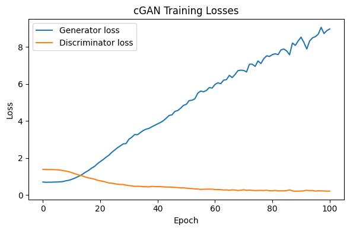

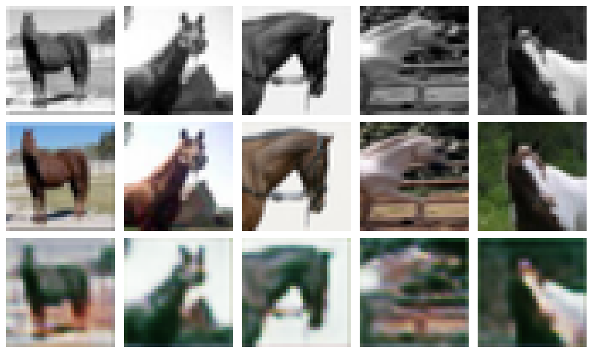

```python
args = AttrDict()
args_dict = {
    "gpu": True,
    "valid": False,
    "checkpoint": "",
    "colours": "./data/colours/colour_kmeans24_cat7.npy",
    "model": "Generator",
    "kernel": 3,
    "num_filters": 16,
    'learn_rate':0.001,
    "batch_size": 50,
    "epochs": 101,
    "seed": 0,
    "plot": False,
    "experiment_name": "colourization_cnn",
    "visualize": False,
    "downsize_input": False,
}
args.update(args_dict)
cnn = train(args)
```

```python
'''
PROVIDE YOUR ANSWER BELOW

The autoencoder shows smooth, stable MSE convergence—good pixelwise reconstructions but typically a bit blurry.
The cGAN curve indicates the discriminator is overpowering (D loss ↓, G loss ↑), so the generator isn’t getting useful gradients.





'''
```